# Práctica R

Alumno: Diego Montaño Martínez

9/3/2021

# Introducción a R

## ¿Qué es R?

- R es un lenguaje de programación y un ambiente de cómputo estadístico
- R es software libre.
- Cuando instalamos R, instala la base de R. Pero la funcionalidad adicional está en **paquetes** programados por terceros.

## ¿Por qué R?

- R funciona en las plataformas más usadas (Mac, Windows, Linux).
- R es un lenguaje de programación completo.
- R promueve la investigación reproducible: procesamiento, análisis y visualización de datos.
- R está actualizado en CRAN hay cerca de 8000 paquetes.
- R se puede combinar con herramientas bioinformáticas y formatos de datos procesados.
- R tiene capacidades gráficas muy sofisticadas, por el paquete ggplot y sus extensiones.
- R es popular como herramienta estadística y bioinformática.
- Los principales paquetes son: de todo tipo de R (CRAN) y especializado en paquetes de bioinformática (Bioconductor).

## Ejercicios

### Ejercicio 1

```r
10-2/8
```

```
## [1] 9.75
```

Divide 2 entre 8, y luego resta el resultado a 10 con operadores. Cuando se encuentra con operaciones múltiples, R sigue el criterio de hacer división y multiplicación antes de suma y resta.

```r
(10-2)/8
```

```
## [1] 1
```

Usando paréntesis, puedes especificar el orden en el cual las operaciones se debe llevar a cabo. Aquellas operaciones dentro de paréntesis se llevaran a cabo antes de las que están fuera del paréntesis. En este caso, la resta antes que la división.

1. Escribe la siguiente operación en una sola linea de código usando operadores: multiplica 5.6 por 11.7, después divide este valor entre 3, sumando 6.6 a este, y elevando todo el resultado a 2.

```r
((5.6 * 11.7 / 3) + 6.6 ) ^ 2
```

```
## [1] 808.8336
```

### Ejercicio 2

```r
rep(x = c("Homo", "sapiens"), times = 7)
```

```
##  [1] "Homo"    "sapiens" "Homo"    "sapiens" "Homo"    "sapiens" "Homo"
##  [8] "sapiens" "Homo"    "sapiens" "Homo"    "sapiens" "Homo"    "sapiens"
```

```r
rep(x = c("Homo", "sapiens"), each = 7)
```

```
##  [1] "Homo"    "Homo"    "Homo"    "Homo"    "Homo"    "Homo"    "Homo"
##  [8] "sapiens" "sapiens" "sapiens" "sapiens" "sapiens" "sapiens" "sapiens"
```

Estos comandos usan la función *rep* para repetir la información en el argumento x.

1. ¿Cómo y por qué los resultados de las dos lineas son diferentes?

Tu respuesta: Las dos llamadas a rep() se hacen con argumentos diferentes, produciendo resultados diferentes en cada caso. En la primera línea se llama con el argumento *times* que recibe un vector de ints, en este caso al tener un valor int, repite ese número de veces el vector *x* en el resultado. En la segunda línea se llama con el argumento *each*, que recibe un int, y repite cada elemento de *x* ese número de veces.

2. Crea un vector que contenga “¡R es asombroso!” 10 veces. Si quieres, usa la función *rep* para ayudarte a completar esta tarea.

```r
rep("¡R es asombroso!", 10)
```

```
##  [1] "¡R es asombroso!" "¡R es asombroso!" "¡R es asombroso!" "¡R es asombroso!"
##  [5] "¡R es asombroso!" "¡R es asombroso!" "¡R es asombroso!" "¡R es asombroso!"
##  [9] "¡R es asombroso!" "¡R es asombroso!"
```

3. Reescribe el código de arriba en 3 diferentes formas:
1. Usando los nombres de los argumentos en su orden predeterminado
2. excluyendo los nombres de los argumentos
3. Cambiando el orden de los argumentos

```r
rep(x="¡R es asombroso!", times=1, length.out=NA, each=10)
```

```
##  [1] "¡R es asombroso!" "¡R es asombroso!" "¡R es asombroso!" "¡R es asombroso!"
##  [5] "¡R es asombroso!" "¡R es asombroso!" "¡R es asombroso!" "¡R es asombroso!"
##  [9] "¡R es asombroso!" "¡R es asombroso!"
```

```r
rep("¡R es asombroso!", 1, NA, 10)
```

```
##  [1] "¡R es asombroso!" "¡R es asombroso!" "¡R es asombroso!" "¡R es asombroso!"
##  [5] "¡R es asombroso!" "¡R es asombroso!" "¡R es asombroso!" "¡R es asombroso!"
##  [9] "¡R es asombroso!" "¡R es asombroso!"
```

```r
rep(each=10, length.out=NA, x="¡R es asombroso!", times=1)
```

```
##  [1] "¡R es asombroso!" "¡R es asombroso!" "¡R es asombroso!" "¡R es asombroso!"
##  [5] "¡R es asombroso!" "¡R es asombroso!" "¡R es asombroso!" "¡R es asombroso!"
##  [9] "¡R es asombroso!" "¡R es asombroso!"
```

### Ejercicio 3

```r
rand_1 <- rnorm(100, mean = 5, sd = 1.5)
```

Crea un objeto con 100 valores aleatorios tomados de una distribución normal con un promedio de 5 y una desviación estándar de 1.5.

1. ¿Qué tipo de objeto es este?

Tu respuesta: Es un vector

2. ¿Qué tipo de datos contiene?

```r
typeof(rand_1)
```

```
## [1] "double"
```

Tu respuesta: Double

3. ¿Cuál es la longitud de este objeto?

```r
length(rand_1)
```

```
## [1] 100
```

4. ¿Cuáles son la media y la desviación estándar de “rand_1”

Tu respuesta: De acuerdo a los valores de los argumentos que pasamos a rnorm la media debería de aproximarse a 5 y la desviación estándar a 1.5

5. Reescriba “rand_1” con otro conjunto de 100 valores aleatorios tomados de una distribución normal con un promedio de 5 y una desviación estándar de 1.5. luego calcúlale la media y la desviación estándar usando funciones de R.

```r
rand_1 = rnorm(100, mean=5, sd=1.5)
mean(rand_1)
```

```
## [1] 5.248536
```

```r
sd(rand_1)
```

```
## [1] 1.548831
```

### Ejercicio 4

```r
exp_mat <- matrix(rpois(1000, 1)*rpois(1000, 10),  nrow = 50)
```

1. ¿Qué hace la función de *rpois*?

Tu respuesta: Regresa un vector de números que siguen la distribución de Poisson con el valor de lambda indicada como argumento

Supongamos que la matriz *exp_mat* es una matriz de los nivels de expresión de genes (filas) en varias muestras (columnas). En matrices como ésta, es útil tener nombres para las filas y las columnas. La siguiente línea de código crea nombres para las columnas que representan diferentes muestras.

2. Hay un error en la línea de abajo, lea el mensaje de error, encuentre el error y solucionelo.

```r
colnames(exp_mat) <- paste("smpl", 1:ncol(exp_mat), sep="_")
```

Explica cual era el error: ncol() esperaba una matriz y le estábamos mandando un string

### Ejercicio 5

1. ¿Qué es el directorio de trabajo:

Tu respuesta: El directorio de trabajo es el cirectorio de trabajo asociado a un proceso. Generalmente es el mismo en donde está almacenado el archivo ejecutable del proceso.

2. Usando tres lineas de código consulta, cambia el directorio de trabajo a donde esté el archivo “Example_expression_set.txt” proporcionado y luego consulta los archivos que contiene tu directorio de trabajo.

```r
getwd()
```

```
## [1] "C:/Users/Diego/Documents"
```

```r
setwd("~/GitHub/ITC/Bioinformatica/Practica_1")
list.files()
```

```
##  [1] "Example_expression_set.txt"
##  [2] "Practica-R.Rmd"
```

### Ejercicio 6

1. Usando la función *read.table* genera un objeto que se llame *exp_mat* y que contenga los datos almacenados en el archivo “Example_expression_set.txt”. Con los parámetros de *read.table*, cuida que los nombres de los renglones y de las columnas queden como etiquetas,

```r
exp_mat = read.table("Example_expression_set.txt", header=TRUE, sep="\t")
```

2. Usando corchetes cuadrados y la función *plot*, grafica los datos contenidos en la primer columna contra los datos de la segunda del objeto *exp_mat*

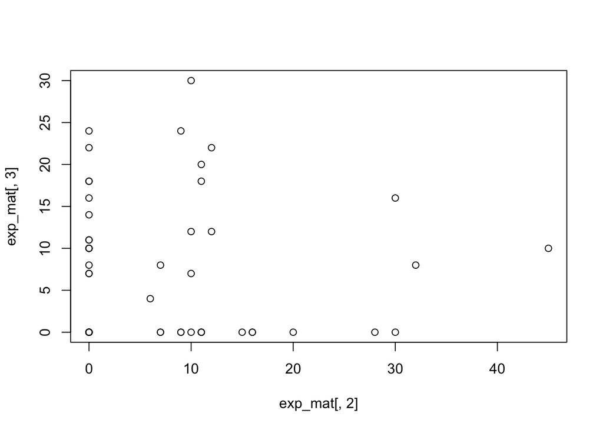

```r
plot(exp_mat[,2], exp_mat[,3])
```

3. Usando *write.table* reescribe la matriz *exp_mat* en un archivo pero esta vez en formato separado por comas (.csv) y nómbralo “exp_mat.csv”.

```r
write.table(exp_mat, "exp_mat.csv", sep=",", row.names=FALSE)
```

4. Guarda un archivo de R (.RData) que contenga el objeto *exp_mat* en un archivo llamado “objetoR.RData”.

```r
save(exp_mat, file="objetoR.RData")
```

5. Guarda el objeto *exp_mat* en formaro RDS en un archivo llamado “exp_mat.RDS”.

```r
saveRDS(exp_mat, "exp_mat.RDS")
```

## Ejercicio 7

```r
data(mtcars)
```

*mtcars* es un objeto con datos de juguete predefinidocon pruebas de carretera de motores de distintas marcas de coches en R. Pueses obtener más datos de este usando *?mtcars*.

```r
head(mtcars)
```

```
##                    mpg cyl disp  hp drat    wt  qsec vs am gear carb
## Mazda RX4         21.0   6  160 110 3.90 2.620 16.46  0  1    4    4
## Mazda RX4 Wag     21.0   6  160 110 3.90 2.875 17.02  0  1    4    4
## Datsun 710        22.8   4  108  93 3.85 2.320 18.61  1  1    4    1
## Hornet 4 Drive    21.4   6  258 110 3.08 3.215 19.44  1  0    3    1
## Hornet Sportabout 18.7   8  360 175 3.15 3.440 17.02  0  0    3    2
## Valiant           18.1   6  225 105 2.76 3.460 20.22  1  0    3    1
```

2. Usando *$* para indexar *mtcars*, haz una gráfica del peso contra las millas/galón.

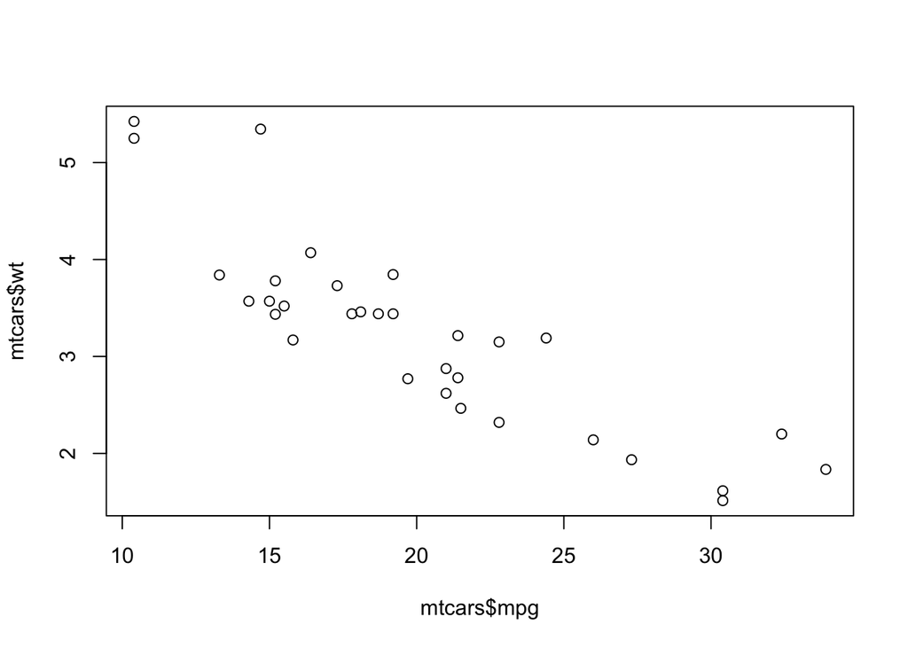

```r
plot(mtcars$mpg, mtcars$wt)
```

3. Usa la función *lm* para ver si hay alguna correlación entre estos dos factores y guarda el resultado en un objeto *res_lm*. Luego usa *summary* para ver los resultados del ajuste del modelo. ¿Cómo interpretarías estos resultados?

Tip: Para ver como se añade una fórmula, revisa los ejemplos de la ayuda de *lm*

```r
res_lm = lm(wt ~ mpg, mtcars)
summary(res_lm)
```

```
##
## Call:
## lm(formula = wt ~ mpg, data = mtcars)
##
## Residuals:
##     Min      1Q  Median      3Q     Max
## -0.6516 -0.3490 -0.1381  0.3190  1.3684
##
## Coefficients:
##             Estimate Std. Error t value Pr(>|t|)
## (Intercept)  6.04726    0.30869  19.590  < 2e-16 ***
## mpg         -0.14086    0.01474  -9.559 1.29e-10 ***
## ---
## Signif. codes:  0 '***' 0.001 '**' 0.01 '*' 0.05 '.' 0.1 ' ' 1
##
## Residual standard error: 0.4945 on 30 degrees of freedom
## Multiple R-squared:  0.7528, Adjusted R-squared:  0.7446
## F-statistic: 91.38 on 1 and 30 DF,  p-value: 1.294e-10
```

## Ejercicio 8

```r
data("iris")
```

Este comando cargue el set de datos de “Iris” de Edgar Anderson.

Los siguientes argumentos se describen en la página de ayuda de la función “plot.default”: “xlim” y “ylim.” Utilize ambos argumentos en este código para modificar la gráfica resultante, la misma que muestra la relación entre dos variables morfológicas para especies de Iris:

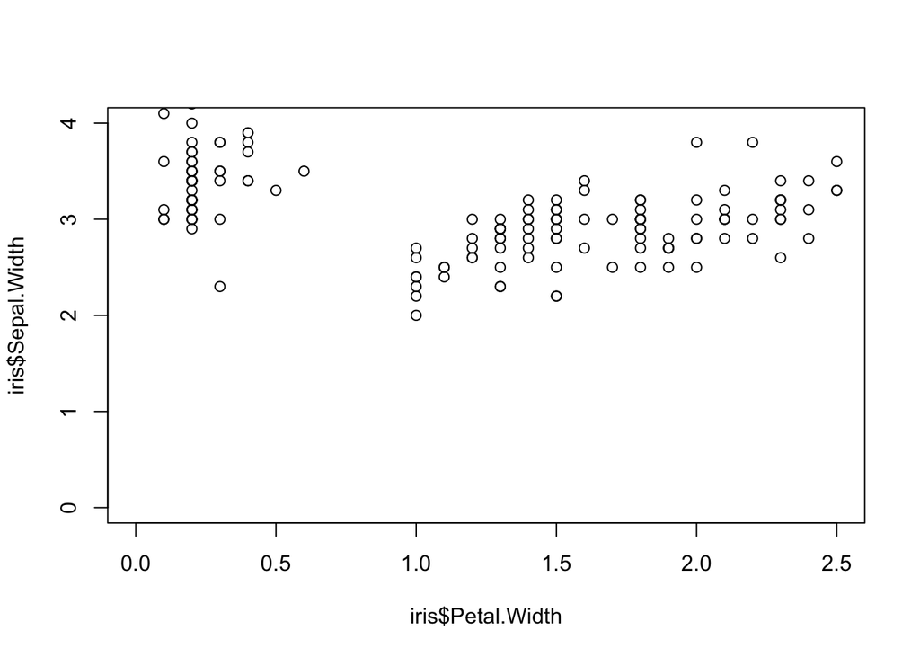

```r
plot(iris$Petal.Width, iris$Sepal.Width, xlim=c(0, 2.5), ylim=c(0, 4))
```

Ve a la página de ayuda para la función “plot.default” y lee sobre estos 6 argumentos:

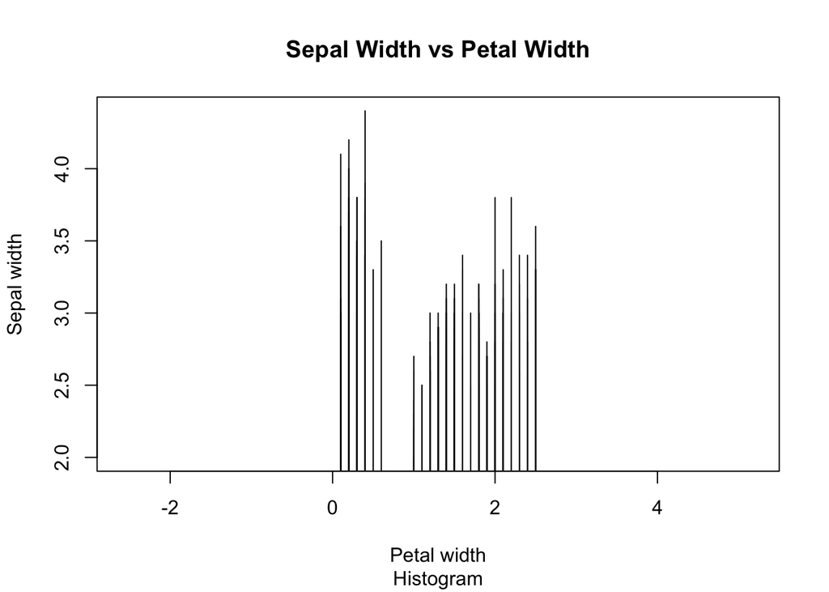

```r
plot(iris$Petal.Width, iris$Sepal.Width, type="h", main="Sepal Width vs Petal Width", sub="Histogram", xlab="Petal width", ylab="Sepal width", asp=16/9)
```

Considere este cambio en el código del inciso anterior:

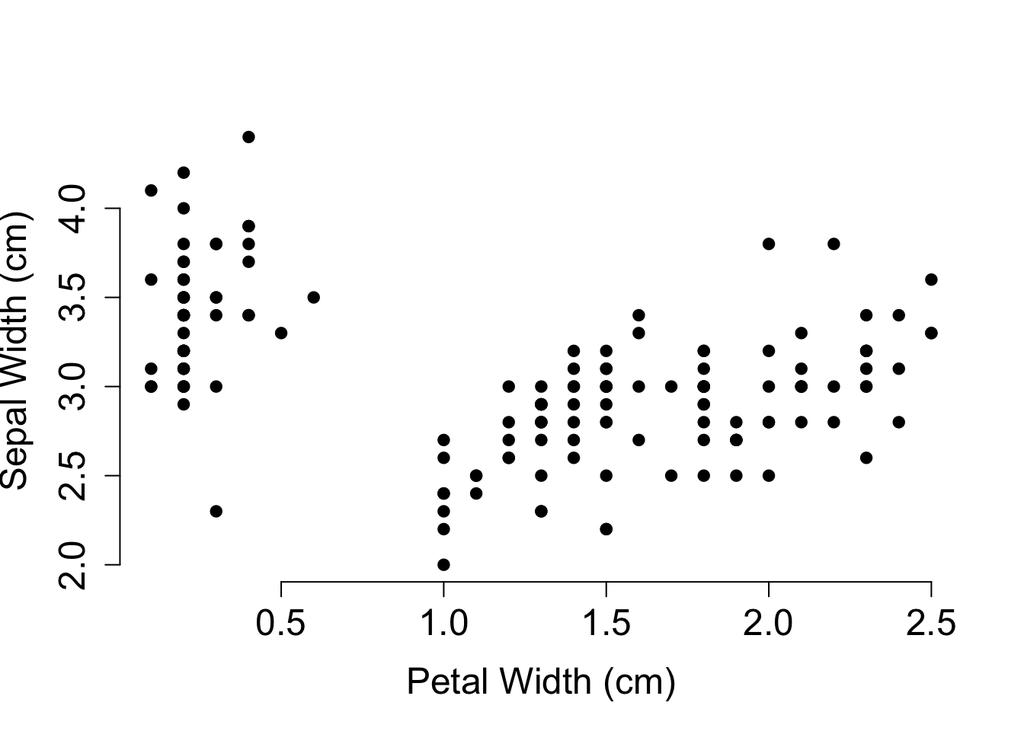

```r
plot(iris$Petal.Width, iris$Sepal.Width,
     xlab="Petal Width (cm)",
     ylab="Sepal Width (cm)",
     cex.axis=1.5,
     cex.lab=1.5,
     bty="n",
     pch=19)
```

Nota el uso del argumento “bty”.

2. Ve a la página de ayuda para la función *par* y lea sobre este argumento. Cambia el valor dado al argumento *bty* 3 veces en el código anterior para ver los resultados que son posible para diferentes valores de *bty*.

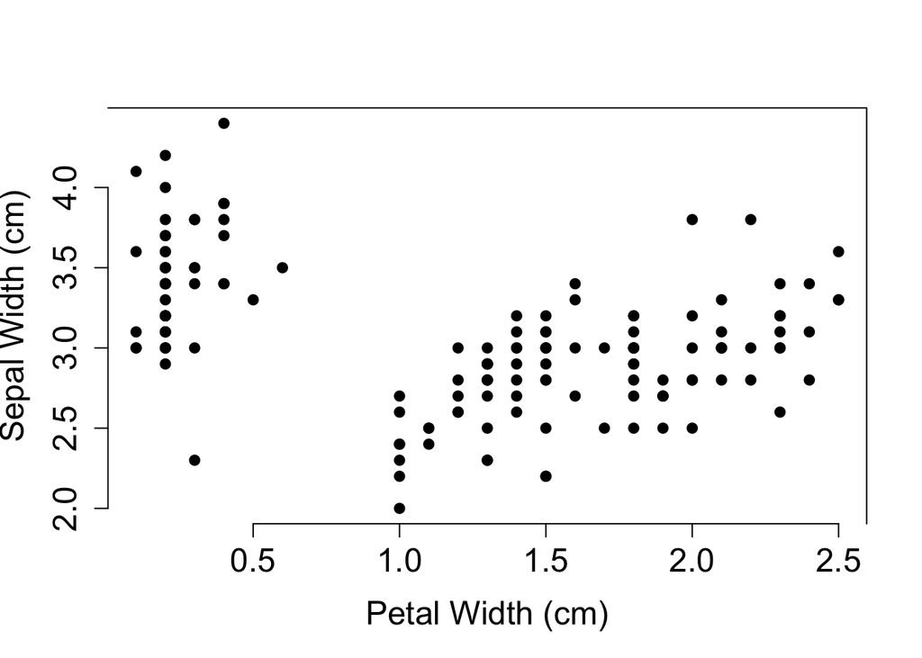

```r
plot(iris$Petal.Width, iris$Sepal.Width,
     xlab="Petal Width (cm)",
     ylab="Sepal Width (cm)",
     cex.axis=1.5,
     cex.lab=1.5,
     bty="7",
     pch=19)
```

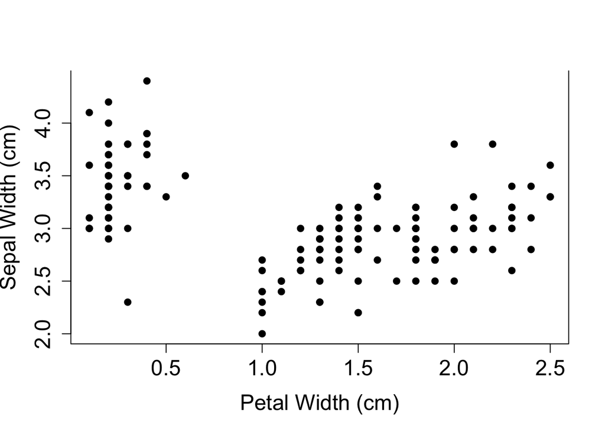

```r
plot(iris$Petal.Width, iris$Sepal.Width,
     xlab="Petal Width (cm)",
     ylab="Sepal Width (cm)",
     cex.axis=1.5,
     cex.lab=1.5,
     bty="U", # haz tus cambios aquí
     pch=19)
```

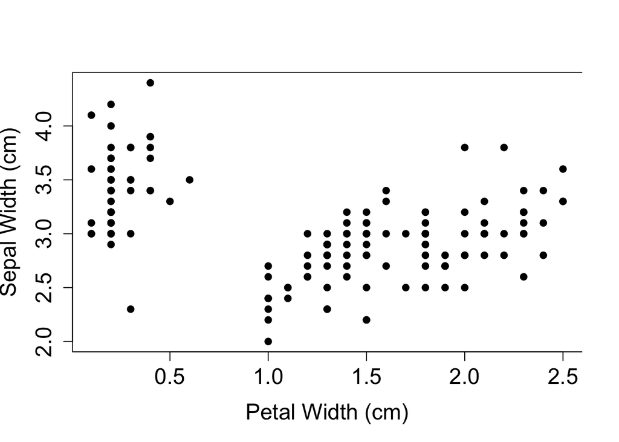

```r
plot(iris$Petal.Width, iris$Sepal.Width,
     xlab="Petal Width (cm)",
     ylab="Sepal Width (cm)",
     cex.axis=1.5,
     cex.lab=1.5,
     bty="C",
     pch=19)
```

## Ejercicio 9

Un bucle permite repetir un pedazo de código múltiples veces sin tener que repetirlo. *for* es la manera mas común de construir bucles. Este tipo de bucle repite un pedazo de código un numero pre-determinado de veces.

La estructura general de un bucle *for* es la siguiente:

#### for(i in v) { code }

Esto quiere decir aproximadamente:

para cada valor que el índice “i” toma del vector “v”, repetir: { este código }

### Ejemplo fácil:

```r
v <- 1:10 # Se define el vector
for(i in v) # Se define la variable que va a "correr" sobre el vector "v"
  {
    print(i) # código que va a ejecutar cada uno de los elementos de "v"
}
```

```
## [1] 1
## [1] 2
## [1] 3
## [1] 4
## [1] 5
## [1] 6
## [1] 7
## [1] 8
## [1] 9
## [1] 10
```

Esto se traduce como:

Crear una secuencia del 1 al 10 y guardarla como un objeto llamado *v* Para cada valor que la variable *i* toma del vector *v* hacer lo siguiente: imprimir el valor de i

1. Escriba un bucle “for” que imprima en pantalla los valores de 5 a 123

```r
for(num in 5:123) print(num)
```

```
## [1] 5
## [1] 6
## [1] 7
## [1] 8
## [1] 9
## [1] 10
## [1] 11
## [1] 12
## [1] 13
## [1] 14
## [1] 15
## [1] 16
## [1] 17
## [1] 18
## [1] 19
```

[output cut: 104 more lines]

2. Escriba un bucle “for” que eleva al cuadrado cada elemento del siguiente vector e imprime los resultados en la pantalla.

```r
x <- c (3,4,6,2,4,9)
for(num in x) print(num * num)
```

```
## [1] 9
## [1] 16
## [1] 36
## [1] 4
## [1] 16
## [1] 81
```

## Ejercicio 10

La función *apply* es usada para aplicar una función a cada elemento de una estructura de datos. En particular, es usada para aplicar funciones en matrices, data frames, arrays o listas. Con esta podemos automatizar tareas complejas usando poca líneas de código y es una de las características distintivas de R como lenguaje de programación.

La funcion *apply* ejecuta la funcion “FUN”, sobre todos las columnas (MARGIN = 2) o renglones (MARGIN = 1) de una matriz.

Uso: apply(X, MARGIN, FUN, …)

Argumentos:

- X: una matriz o cualquier otro objeto que sea posible convertir en una matriz
- MARGIN: Define sobre qué se va ejecutar la función y toma valores entre 1 y 2:
- MARGIN=1: La manipulación se hace por renglón.
- MARGIN=2: La manipulación se hace por columnas.
- MARGIN=c(1,2): La manipulación se hace por renglones y columnas.
- FUN: Indica que función se aplicará.

Se puede usar funciones integradas como *mean*, *median*, *sum*, *min*, *max* e incluso funciones definidas por el usuario.

### Ejemplo sencillo

Creamos una matriz ejemplo de cuatro renglones

```r
matriz <- matrix(1:16, nrow = 4)
```

Aplicamos *apply*, dando la función *sum* como el argumento “FUN”. Nota que solo necesitamos el nombre de la función sin usar paréntesis. Por último, damos el argumento MARGIN = 1, para aplicar la función a los renglones.

```r
apply(X = matriz, MARGIN = 1, FUN = sum)
```

```
## [1] 28 32 36 40
```

Esto es equivalente a hacer lo siguiente:

```r
sum(matriz[1, ])
```

```
## [1] 28
```

```r
sum(matriz[2, ])
```

```
## [1] 32
```

```r
sum(matriz[3, ])
```

```
## [1] 36
```

```r
sum(matriz[4, ])
```

```
## [1] 40
```

Si cambiamos el argumento “MARGIN” de “MARGIN = 1” a “MARGIN = 2”, entonces la función se aplicará a todas las columnas.

```r
apply(X = matriz, MARGIN = 2, FUN = sum)
```

```
## [1] 10 26 42 58
```

O sea, el equivalente a hacer lo siguiente:

```r
sum(matriz[, 1])
```

```
## [1] 10
```

```r
sum(matriz[, 2])
```

```
## [1] 26
```

```r
sum(matriz[, 3])
```

```
## [1] 42
```

```r
sum(matriz[, 4])
```

```
## [1] 58
```

1. Usando *apply* calcula primero la media y luego, con un segundo comando, la desviación estándar de todas las variables (columnas) del conjunto de datos *mtcars*.

```r
apply(mtcars, 2, mean)
```

```
##        mpg        cyl       disp         hp       drat         wt       qsec
##  20.090625   6.187500 230.721875 146.687500   3.596563   3.217250  17.848750
##         vs         am       gear       carb
##   0.437500   0.406250   3.687500   2.812500
```

```r
apply(mtcars, 2, sd)
```

```
##         mpg         cyl        disp          hp        drat          wt
##   6.0269481   1.7859216 123.9386938  68.5628685   0.5346787   0.9784574
##        qsec          vs          am        gear        carb
##   1.7869432   0.5040161   0.4989909   0.7378041   1.6152000
```

2. Busca *lapply* en la ayuda y resuelve con ella la misma pregunta que el inciso anterior.

```r
lapply(mtcars, mean)
```

```
## $mpg
## [1] 20.09062
##
## $cyl
## [1] 6.1875
##
## $disp
## [1] 230.7219
##
## $hp
## [1] 146.6875
##
## $drat
## [1] 3.596563
##
## $wt
## [1] 3.21725
##
## $qsec
## [1] 17.84875
##
## $vs
## [1] 0.4375
##
## $am
## [1] 0.40625
##
## $gear
## [1] 3.6875
##
## $carb
## [1] 2.8125
```

```r
lapply(mtcars, sd)
```

```
## $mpg
## [1] 6.026948
##
## $cyl
## [1] 1.785922
##
## $disp
## [1] 123.9387
##
## $hp
## [1] 68.56287
##
## $drat
## [1] 0.5346787
##
## $wt
## [1] 0.9784574
##
## $qsec
## [1] 1.786943
##
## $vs
## [1] 0.5040161
##
## $am
## [1] 0.4989909
##
## $gear
## [1] 0.7378041
##
## $carb
## [1] 1.6152
```

3. ¿En qué difieren *apply* y *lapply*?

Tu respuesta: De acuerdo con la documentación *apply* recibe un arreglo, data frame o matriz y regresa un vector, lista o arreglo. Mientras que *lapply* recibe un vector o un objeto y regresa una lista.